# Instructions

You’re almost done with the semester! Take a second to congratulate yourself on getting here. As a reminder, this final project is simply an (imperfect) way of measuring what you have learned throughout the semester. So take a deep breath and do your best, but also remember that it doesn’t determine your value as a human being.

The exam is split into 4 sections: Module 1, 2 and 3 (6 questions), Modules 4 and 5 (3 questions), Module 6 (2 questions) and the final project. Most of the questions on this exam are short answers. You don’t need to write out an overly long response (a sentence or so for each part of the question should be fine), but you should be specific in explaining your response. For example, if there is a question about whether the assumptions are reasonable. You shouldn’t just say “from the plot we can see that the linearity assumption is (or is not) reasonable,” but instead you should explain specifically why the plot leads you to believe the linearity assumption is (or is not) reasonable.

The exam is open notes so you **can** use any of the material or any of the notes you have taken throughout the class. You **cannot** discuss the exam (while it is in progress) with anyone else. You also **cannot** use any generative AI tools. Submissions will be sent by e-mail to **nbb45@cornell.edu** before **May 14th 11:59pm**.

# Module 1, 2, and 3

In the questions for Modules 1, 2, and 3, we will look at data from SNCF, France’s national railway. The data has been cleaned and made easily available by [TidyTuesday](https://github.com/rfordatascience/tidytuesday/tree/master/data/2019/2019-02-26). In particular, we have data on train delays from each month between 2015-2018 for each train route (i.e., from city A to city B). So each observation (i.e., row in the data) corresponds to a specific route in a specific year and month. In the dataset, we will be particularly interested in the following variables

For each row in the data, we have the following variables

- year : year of observation (2015, 2016, 2017 or 2018)
- month : month of observation (1, 2, …, 12)
- departure_station : station where the route begins (e.g., “PARIS NORD” or “MONTPELLIER”)
- arrival_station : station where the route ends (e.g., “PARIS NORD” or “MONTPELLIER”)
- journey_time_avg : average journey time in minutes for the route for that year and month
- avg_delay_all_departing : average delay in minutes for all departures for the route for that year and month (i.e., how many minutes the train was late to leave departure station)
- avg_delay_all_arriving : average delay in minutes for all arrivals for the route for that year and month (i.e., how many minutes the train was late to arrive at the arrival_station)

In the following questions, the model you fit or consider may change from question to question.

```r
## Load in data and remove some outliers
train_data <- read.csv("https://raw.githubusercontent.com/rfordatascience/tidytuesday/master/data/2019/2019-02-26/small_trains.csv")
# removing some outliers
train_data <- train_data[-which(train_data$avg_delay_all_arriving < -30),]
train_data <- train_data[-which(train_data$avg_delay_all_departing > 30),]
# make month and year factors
train_data$month <- as.factor(train_data$month)
train_data$year <- as.factor(train_data$year)
```

## Question 1 (2 pts)

Suppose we are interested in modeling the average delayed arrival; i.e., avg_delay_all_arriving is the outcome variable. Specifically, we would like to investigate the association between average delayed arrival and journey time (journey_time_avg) when controlling for the average departure delay (avg_delay_all_departing).

Fit the relevant linear model below and write 1 sentence interpreting the estimated coefficient for journey_time_avg.

#### Question 1 Answer

```r
##average daily arrival model
library(ggplot2)
av_daily_arr_model = lm(avg_delay_all_arriving ~ journey_time_avg + avg_delay_all_departing, data = train_data)
av_daily_arr_model
```

```
##
## Call:
## lm(formula = avg_delay_all_arriving ~ journey_time_avg + avg_delay_all_departing,
##     data = train_data)
##
## Coefficients:
##             (Intercept)         journey_time_avg  avg_delay_all_departing
##                -0.35134                  0.02208                  0.85284
```

```r
coef(av_daily_arr_model)
```

```
##             (Intercept)        journey_time_avg avg_delay_all_departing
##             -0.35134364              0.02207673              0.85283952
```

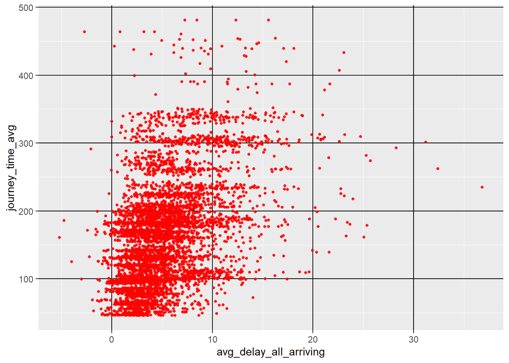

```r
ggplot(av_daily_arr_model, aes(x = avg_delay_all_arriving, y = journey_time_avg)) + geom_point(color = "red", size = 1, alpha = 0.3) +  theme(panel.grid.major = element_line(color = "black"))
```

## Question 2 (2 pts)

Some output for a **different model** is shown below. Using the output, predict the average arrival delay for a train route which has an average journey time of 200 minutes, has an average departure delay of 3 minutes, and took place in January (i.e., month == 1).

```
##                            Estimate   Std. Error    t value      Pr(>|t|)
## (Intercept)             -0.89153617 0.0625821018 -14.245865  6.529044e-46
## journey_time_avg         0.02215535 0.0001925167 115.082758  0.000000e+00
## avg_delay_all_departing  0.79854766 0.0067729269 117.902891  0.000000e+00
## month2                   0.45637989 0.0735194856   6.207605  5.444405e-10
## month3                  -0.47362582 0.0734957887  -6.444258  1.177825e-10
## month4                  -0.08049415 0.0735030454  -1.095113  2.734751e-01
## month5                   0.32511688 0.0735458330   4.420602  9.874291e-06
## month6                   1.86150670 0.0739347360  25.177701 1.475638e-138
## month7                   1.94714571 0.0742472465  26.225157 4.916823e-150
## month8                   0.75296105 0.0737335963  10.211913  1.908528e-24
## month9                   0.61577106 0.0735351836   8.373829  5.797172e-17
## month10                  0.93242762 0.0734938111  12.687158  8.508994e-37
## month11                  1.29220290 0.0736160461  17.553278  1.160711e-68
## month12                  0.13960420 0.0810379232   1.722702  8.495186e-02
```

[figure not shown]

[figure not shown]

[figure not shown]

[figure not shown]

```
##
## Call:
## lm(formula = avg_delay_all_arriving ~ journey_time_avg + avg_delay_all_departing +
##     month, data = train_data)
##
## Coefficients:
##             (Intercept)         journey_time_avg  avg_delay_all_departing
##                -0.89154                  0.02216                  0.79855
##                  month2                   month3                   month4
##                 0.45638                 -0.47363                 -0.08049
##                  month5                   month6                   month7
##                 0.32512                  1.86151                  1.94715
##                  month8                   month9                  month10
##                 0.75296                  0.61577                  0.93243
##                 month11                  month12
##                 1.29220                  0.13960
```

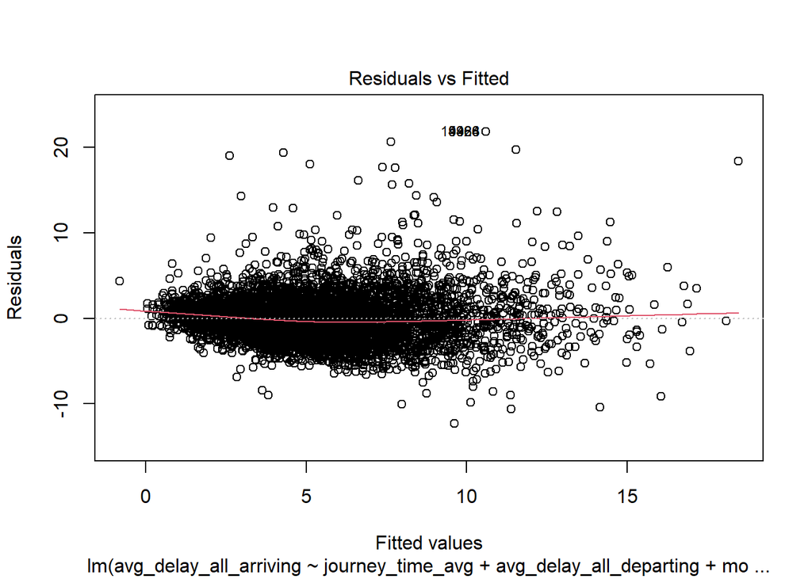

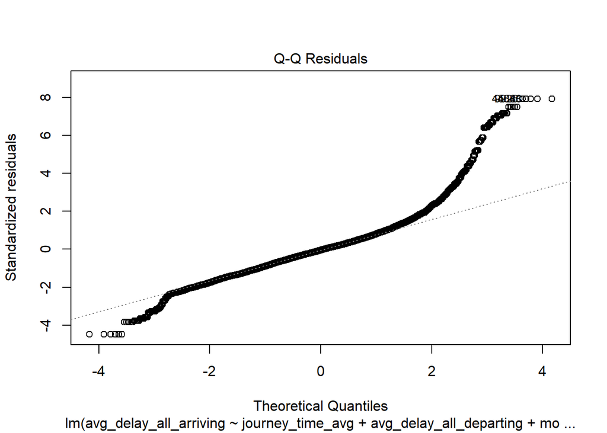

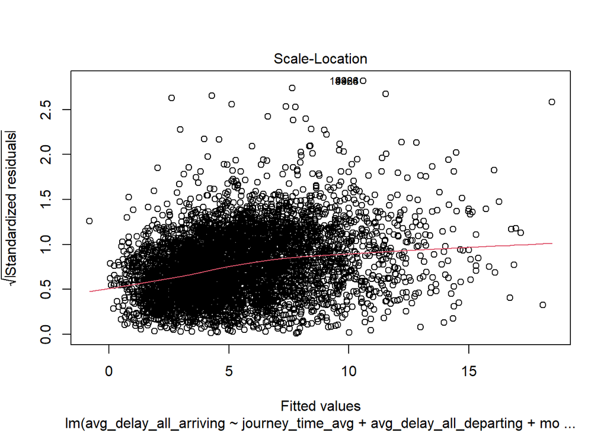

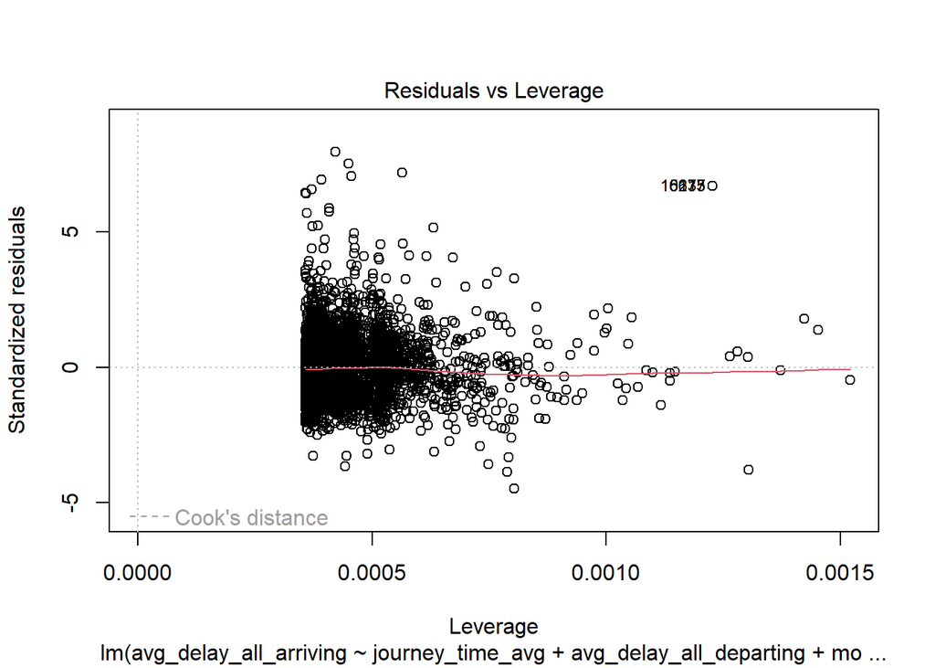